# Seaborn을 활용하면 시각화가 쉬워 집니다(사실 외울게 많습니다...ㅠㅠ)

먼저 터미널이나 명령 프롬포트에서 **pip install seaborn**을 입력하여 seaborn 모듈을 설치 합니다. 좀더 예쁘게 시각화 할 수 있도록 도와줍니다  
먼저 seaborn을 사용하지 않고 matplot만 사용하여 그래프를 그려 보겠습니다

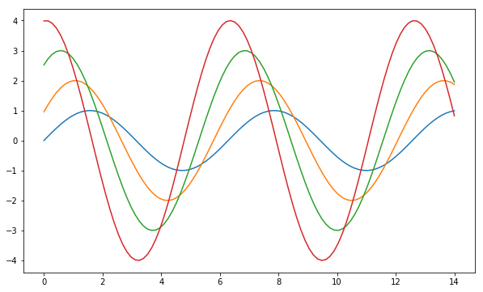

```python
import matplotlib.pyplot as plt
import numpy as np
%matplotlib inline

x = np.linspace(0, 14, 100)

y1 = np.sin(x)
y2 = 2*np.sin(x+0.5)
y3 = 3*np.sin(x+1.0)
y4 = 4*np.sin(x+1.5)

plt.figure(figsize=(10,6))
plt.plot(x, y1, x,y2, x,y3, x,y4)
plt.show()
```

예쁘긴 하지만 이번엔 seaborn을 활용해서 여러가지 스타일을 지정해 보겠습니다. seaborn을 사용 할 때 반드시 matplotlib 모듈도 같이 import 되어 있어야 합니다

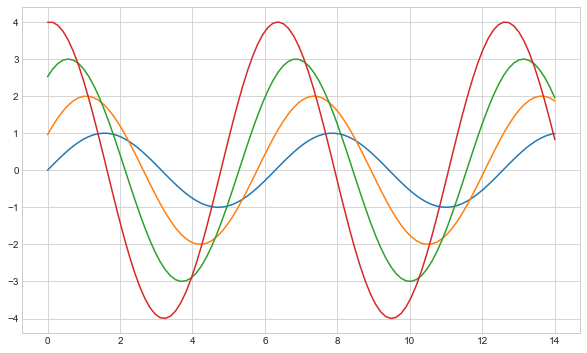

```python
import seaborn as sns

sns.set_style('whitegrid') # seaborn의 whitegrid 스타일 지정하기

plt.figure(figsize=(10,6))
plt.plot(x,y1, x,y2, x,y3, x,y4)
plt.show()
```

Seaborn에 있는 몇가지 연습 데이터셋을 사용 해 보도록 하겠습니다. 먼저 요일별 점심, 저녁, 흡연 여부와 식사 금액과 팁을 정리한 데이터 입니다

```python
import matplotlib.pyplot as plt
import numpy as np
import seaborn as sns

sns.set_style('whitegrid')
%matplotlib inline

tips = sns.load_dataset('tips') # seaborn 에서 기본적으로 제공하는 tips 데이터셋 불러오기
tips.head()
```

|  | total_bill | tip | sex | smoker | day | time | size |
| --- | --- | --- | --- | --- | --- | --- | --- |
| 0 | 16.99 | 1.01 | Female | No | Sun | Dinner | 2 |
| 1 | 10.34 | 1.66 | Male | No | Sun | Dinner | 3 |
| 2 | 21.01 | 3.50 | Male | No | Sun | Dinner | 3 |
| 3 | 23.68 | 3.31 | Male | No | Sun | Dinner | 2 |
| 4 | 24.59 | 3.61 | Female | No | Sun | Dinner | 4 |

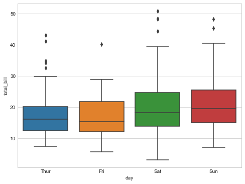

```python
plt.figure(figsize=(8,6))
sns.boxplot(x='day', y='total_bill', data=tips) #  박스 그래프 로 보기. x축은 day(요일), y축은 전체 금액(total_bill)
plt.show()
```

위 데이터는 단순히 요일별 매출을 시각화 해본 그래프 입니다. 이것만으로도 충분히 시각화가 쉬워지지만,  
**hue**라는 옵션을 이용하면 또다른 데이터를 이용해서 데이터를 구분 해 볼 수 있습니다.

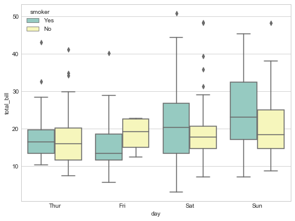

```python
plt.figure(figsize=(8,6))
sns.boxplot(x='day', y='total_bill', hue='smoker', data=tips, palette='Set3') # 흡연자(smoker)로 추가 구분하기
plt.show()
```

위의 그래프를 확인 해보면 흡연자가 더 결제범위가 큰 것이 확인됩니다

이번엔 약간 다른 스타일의 그래프를 그려 보겠습니다. 결제 금액과 종업원에게 주는 팁에 대한 회귀 분석 시각화 입니다.  
lmplot을 활용하면 간단하게 데이터 분석이 가능합니다.

# 적절한 상관계수를 확인 할 때 사용하기 좋은 lmplot

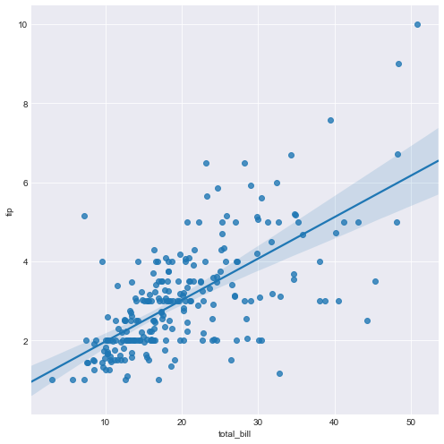

```python
sns.set_style('darkgrid') # darkgrid 스타일의 그래프 그리기
sns.lmplot(x='total_bill', y='tip', data=tips, size=7) # x축 결제금액, y축 종업원에게 주는 팁
plt.show()
```

회기 분석은 간단하게 말해서 예전에 그려봤던 상관계수라고 보시면 될 것 같습니다.  
일전에 상관계수를 데이터와 데이터 사이에 상관 정도를 구해서 분석의 용도로 활용 했는데, 회기 분석은 그 상관관계를 구하는 조금 더 정확한 방법 이라고 보시면 될 것 같습니다.  
즉 위의 그래프에서 제시하는 결제금액에 따른 적절한 팁 액수를 확인 할 수 있다는 것입니다.  
아무튼 지금은 total_bill과 tip은 양의 상관 관계를 갖는다 라고 이야기 합니다.( total_bill이 많아 질수록 tip이 많아지네요)  
또한 유효한 범위까지 그림으로 그려주는 것이 확인 됩니다. hue를 이용해서 흡연자로 비교해 보겠습니다

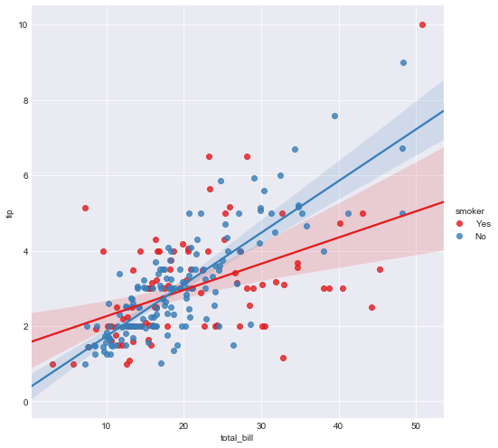

```python
sns.lmplot(x='total_bill', y='tip', hue='smoker', data=tips, palette='Set1', size=7) #흡연자 데이터로 비교하기
plt.show()
```

lmplot 시각화도 hue옵션을 가질 수 있고 palette 옵션을 이용해 색상도 지정해 주었습니다.

## 다음은 연도 및 월별 항공기 승객수를 기록한 데이터 입니다

```python
flights = sns.load_dataset("flights")
flights.head()
```

|  | year | month | passengers |
| --- | --- | --- | --- |
| 0 | 1949 | January | 112 |
| 1 | 1949 | February | 118 |
| 2 | 1949 | March | 132 |
| 3 | 1949 | April | 129 |
| 4 | 1949 | May | 121 |

연도 및 월별 항공기 승객수로 구분하기 위해 pivot_table을 활용 하겠습니다.

```python
flights = flights.pivot("month", "year", "passengers") #month별, year컬럼, passengers 데이터
flights.head()
```

| year month | 1949 | 1950 | 1951 | 1952 | 1953 | 1954 | 1955 | 1956 | 1957 | 1958 | 1959 | 1960 |
| --- | --- | --- | --- | --- | --- | --- | --- | --- | --- | --- | --- | --- |
| January | 112 | 115 | 145 | 171 | 196 | 204 | 242 | 284 | 315 | 340 | 360 | 417 |
| February | 118 | 126 | 150 | 180 | 196 | 188 | 233 | 277 | 301 | 318 | 342 | 391 |
| March | 132 | 141 | 178 | 193 | 236 | 235 | 267 | 317 | 356 | 362 | 406 | 419 |
| April | 129 | 135 | 163 | 181 | 235 | 227 | 269 | 313 | 348 | 348 | 396 | 461 |
| May | 121 | 125 | 172 | 183 | 229 | 234 | 270 | 318 | 355 | 363 | 420 | 472 |

# 값별 수치를 색상으로! heatmap을 사용하여 데이터 확인하기

heatmap을 활용하면 수치 별 시각화를 정말 쉽게 확인 할 수 있습니다. 일전 데이터를 보고 pivot을 활용한다면 heatmap으로 데이터를 확인해보세요!

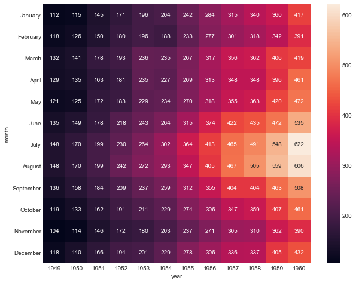

```python
plt.figure(figsize=(10,8))
sns.heatmap(flights, annot=True, fmt="d")
plt.show()
```

## 각 항목별 비교로 확인해 보기 pairplot

머신러닝에서 많이 사용되는 아이리스 꽃에 대한 데이터 입니다. 각각의 데이터가 의미 하는 바는 다음과 같습니다.

- Species : 붓꽃의 종. setosa, versicolor, virginica 세 가지 값 중 하나
- Sepal.Width : 꽃받침의 너비
- Sepal.Length : 꽃받침의 길이
- Petal.Width : 꽃잎의 너비
- Petal.Length : 꽃잎의 길이

```python
sns.set(style='ticks')
iris = sns.load_dataset('iris')
iris.head(10)
```

|  | sepal_length | sepal_width | petal_length | petal_width | species |
| --- | --- | --- | --- | --- | --- |
| 0 | 5.1 | 3.5 | 1.4 | 0.2 | setosa |
| 1 | 4.9 | 3.0 | 1.4 | 0.2 | setosa |
| 2 | 4.7 | 3.2 | 1.3 | 0.2 | setosa |
| 3 | 4.6 | 3.1 | 1.5 | 0.2 | setosa |
| 4 | 5.0 | 3.6 | 1.4 | 0.2 | setosa |
| 5 | 5.4 | 3.9 | 1.7 | 0.4 | setosa |
| 6 | 4.6 | 3.4 | 1.4 | 0.3 | setosa |
| 7 | 5.0 | 3.4 | 1.5 | 0.2 | setosa |
| 8 | 4.4 | 2.9 | 1.4 | 0.2 | setosa |
| 9 | 4.9 | 3.1 | 1.5 | 0.1 | setosa |

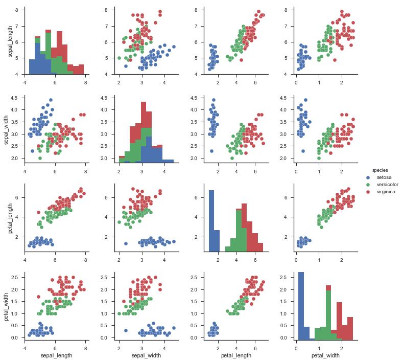

```python
sns.pairplot(iris, hue='species') # 꽃 종류별 데이터 비교 분석 하기
plt.show()
```

아주 간단하게 데이터 분석이 가능해집니다. 아이리스 예제는 인공지능 머신러닝에서 매우 중요하게 다뤄지는 예제 입니다.

# 이제 본격적으로 범죄 데이터를 시각화 해보겠습니다.